# SIR temptative model

Angela Carraro, Giullia Monteiro Milano Oliveira, Gaia Saveri

3/07/2020

```r
library(readr)
library(rstan)
library(dplyr)
library(ggplot2)
library(bayesplot)
library(lubridate)
```

## The SIR model

The SIR model (which is an acronym for Susceptible, Infected, Recovered or Removed) is a *population-based* model, which subdivide the population into homogeneous time-dependent groups, called *compartments*. The flows between compartments can be described by a system of ODEs.

The temporal dynamic of the sizes of each of the compartmnerts are governed by the following system of ODEs:

$$\frac{dS}{dt} = -\beta\cdot S \cdot \frac{I}{N} \\
\frac{dI}{dt} = \beta \cdot S \cdot \frac{I}{N} - \gamma\cdot I \\
\frac{dR}{dt} = \gamma\cdot I$$

where $S(t)$ is the number of people suscptible to becoming infected, $I(t)$ is the number of people currently infected, $R(t)$ is the number of people that are recovered or removed (dead).

The $\beta$ is called *effective contact rate* and controls the rate of spread which represents the probability of transmitting disease between a susceptible and an infectious individual.

The $\gamma$ is called *recoverity and mortality* rate and it is determined by the average duration of infection.

Assumption behind this model are that:

- $N=S+I+R$ remains constant, namely births and deaths (except the ones due to the disease) are not contributing to the dynamics;
- recovered individual cannot be susceptible again (full immunity);
- infection rate and recovery rate are constant;
- individuals meet any other individual uniformely at random and recovery time follows an exponential distribution woth mean $\frac{1}{\gamma}$.

This is the mathematical framework of the SIR model, now we need to give it a statistical formulation.

## Statistical model

Let’s start by the likelihood, also called *sampling distribution* $p(Y|\theta)$ which tells us, given the parameters, how to generate the data. We want to link the solution we get from the ODEs to the observed data. Let’s say that $\hat{I}(t)$ are the number of infected people at time $t$ as predictedd by the SIR model, while $I(t)$ is the number of observed infected people at time $t$ (comfirmed cases as given by our data).

As we proposed in other models (the class of glm) we can model the number of infected people with a count distribution, such as the Negative Binomial, having $\hat{I}(t)$ as expected value and a parameter $\phi$ that allows for overdispersion.

$$I(t) \sim \mathcal{NagativeBinomial}(\hat{I}(t), \phi)$$

With this model, the set of parameters we have to deal with now is $\theta = (\beta, \gamma, \phi)$.

Being our model a Bayesian one, we need to put a prior (which encodes the information about the parameters we have before observing the data) over these parameters, $p(\theta)$.

We can use non-informative priors for them such as:

$$\beta \sim \mathcal{N}(2,1) \\
\gamma \sim \mathcal{N}(0.4, 0.5) \\
\frac{1}{\phi} \sim \mathcal{Exp}(5)$$

Having the likelihood and the prior, we are at this point ready to apply Bayes theorem to estimate the posterior $p(\theta|Y) \propto p(Y|theta)\cdot p(\theta)$, by fitting the model.

Then we can compute a posterior distribution of predictions $p(Y_{pred}|Y) = \int p(Y_{pred}|\theta)p(\theta|Y)d\theta$.

A very famous and important qauntity that depends on the model parameters, hence we can compute, is the basic reproduction number $R_0$, defined as the expected number of secondary infections produced from one infected individual in a fully susceptible population through the entire duration of the infectious period.

By means of Bayesian inference we can build a posterior for $R_0$, that being $p(R_0|Y)$.

## Building the model

Guess what.. need to fix the data!

```r
data<-read_csv("data/SIR_data.csv")
data<- data %>% select(-X1)
data<-data[,c(1,3,2)]
missing.data<-read_csv("data/dead_recovered.csv")
missing.data<-missing.data %>% select(-"confirmed")
missing.data<-missing.data %>% select(-"confirmed_daily")
missing.data<-missing.data[-1,]
missing.data<-missing.data[-c(2,3,5),]
deaths<-missing.data$deaths
recovered<-missing.data$recovered

data$`cumulative_deaths`<-deaths
data$`cumulative_recoveries`<-recovered
#pop in millions
bogotà_pop<-7.4
antioquia_pop<-6.4
cundimarca_pop<-2.9
caldas_pop<-0.99
valle_cauca_pop<-4.4
meta_pop<-1
risaralda_pop<-0.94
santander_pop<-2.1
quindio_pop<-0.53
tolima_pop<-1.3
cauca_pop<-1.4
casanare_pop<-0.42
boyaca_pop<-1.2

tot_pop<-N<-7.4+6.4+2.9+0.99+4.4+1+0.94+2.1+0.53+1.3+1.4+0.42+1.2
N<-N*10^6 #from millions to individuals
```

We can compute the S-I-R quantities we need as follows:

- S := Susceptible = All - Confirmed;
- I := Infected = Confirmed - Recovered - Deaths;
- R := Recovered or fatal = Recovered + Deaths.

```r
All<-as.vector(rep(N,25))
data$S<-All-data$y
data$I<-data$y-data$cumulative_deaths-data$cumulative_recoveries
data$R<-data$cumulative_deaths+data$cumulative_recoveries

SIR.data<-data[,c(2,3,6,7,8)]
head(SIR.data)
```

```
## # A tibble: 6 x 5
##   elapsed_time     y        S     I     R
##          <dbl> <dbl>    <dbl> <dbl> <dbl>
## 1            0     1 30979999     1     0
## 2            3     3 30979997     3     0
## 3            5     9 30979991     9     0
## 4            6    11 30979989    11     0
## 5            7    16 30979984    16     0
## 6            8    24 30979976    24     0
```

Let’s fix things up to fix the stan model:

```r
cases<-SIR.data$y
n_days<-length(cases)
t<-seq(0, n_days, by=1)
#I.C. for the ODEs
t0<-0
t<-t[-1]
i0<-1
s0<-N-i0
r0<-0
y0 = c(S=s0, I=i0, R=r0)

Sir.data<-list(n_days = n_days,
               y0 = y0,
               t0 = t0,
               ts = t,
               N = N,
               cases = cases)

#compile the model
Sir.model<-stan_model("stan/SIR.stan")
```

[output not shown]

```r
#run the model
fit.model<-sampling(Sir.model, data=Sir.data)
```

Let’s check the correctness of the nference of the model:

```r
pars<-c("beta", "gamma", "R0", "recovery_time")
print(fit.model, pars=pars)
```

```
## Inference for Stan model: SIR.
## 4 chains, each with iter=2000; warmup=1000; thin=1;
## post-warmup draws per chain=1000, total post-warmup draws=4000.
##
##                mean se_mean     sd 2.5%  25%  50%   75%  97.5% n_eff Rhat
## beta           0.59    0.04   0.16 0.38 0.46 0.56  0.67   0.98    17 1.12
## gamma          0.21    0.04   0.16 0.01 0.09 0.19  0.30   0.61    17 1.12
## R0            12.36    2.72 103.72 1.61 2.26 3.00  5.15  52.72  1452 1.00
## recovery_time 30.39    7.26 275.49 1.63 3.38 5.39 11.15 140.25  1439 1.00
##
## Samples were drawn using NUTS(diag_e) at Tue Jun 30 23:37:55 2020.
## For each parameter, n_eff is a crude measure of effective sample size,
## and Rhat is the potential scale reduction factor on split chains (at
## convergence, Rhat=1).
```

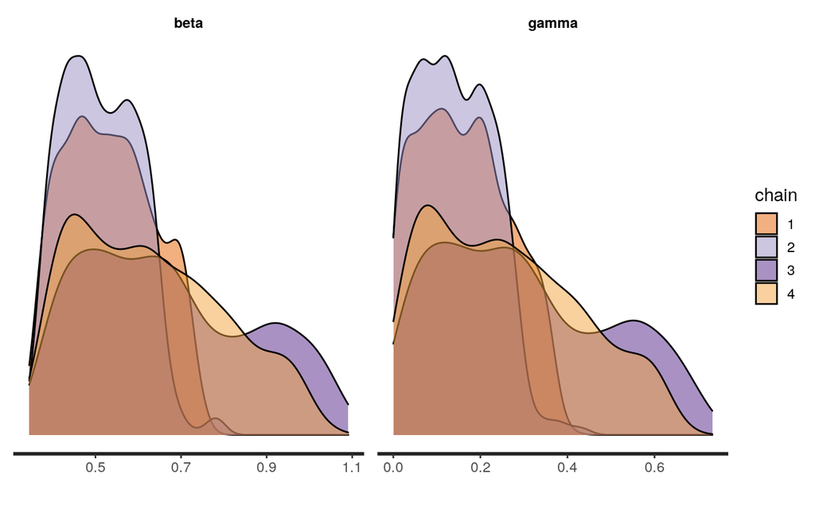

```r
stan_dens(fit.model, pars=c("beta", "gamma"), separate_chains=TRUE)
```

looking at $\hat{R}$ we can see that it is $1$ for `R0` and `recovery_time`, but it is a little higher for the other two, moreover for `beta` and `gamma` the `n_eff` is really low.. this could be a symptom of the poorly mixing of the Markov chains (maybe we need to take stronger priors).

Indeed Markov chains do not agree much.

```r
#compile the model
Sir.model2<-stan_model("stan/SIR.stan")

#run the model
fit.model2<-sampling(Sir.model2, data=Sir.data)
pars<-c("beta", "gamma", "R0", "recovery_time")
print(fit.model2, pars=pars)
```

```
## Inference for Stan model: SIR.
## 4 chains, each with iter=2000; warmup=1000; thin=1;
## post-warmup draws per chain=1000, total post-warmup draws=4000.
##
##                mean se_mean     sd 2.5%  25%  50%  75% 97.5% n_eff Rhat
## beta           0.65    0.05   0.22 0.38 0.48 0.60 0.79  1.09    19  1.2
## gamma          0.28    0.05   0.22 0.02 0.10 0.23 0.41  0.72    18  1.2
## R0             7.45    1.65  59.12 1.52 1.90 2.63 4.50 25.91  1287  1.0
## recovery_time 17.43    4.52 162.17 1.39 2.42 4.41 9.53 66.66  1288  1.0
##
## Samples were drawn using NUTS(diag_e) at Tue Jun 30 23:41:11 2020.
## For each parameter, n_eff is a crude measure of effective sample size,
## and Rhat is the potential scale reduction factor on split chains (at
## convergence, Rhat=1).
```

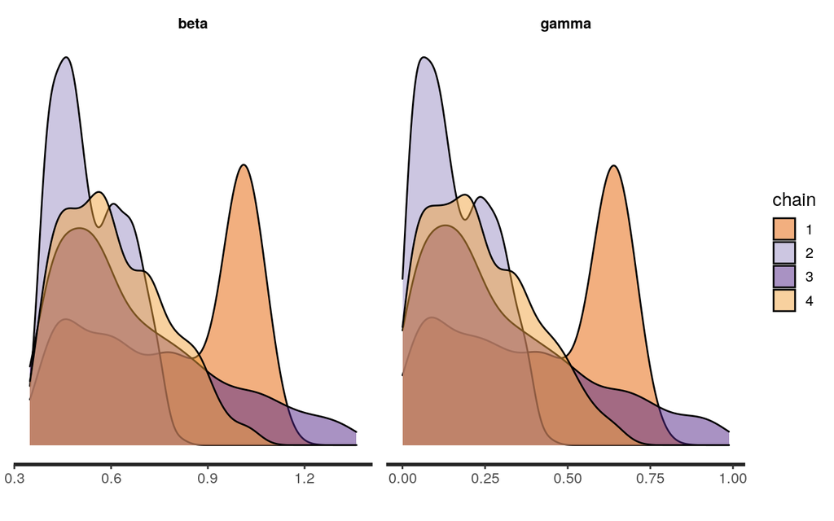

```r
stan_dens(fit.model2, pars=c("beta", "gamma"), separate_chains=TRUE)
```

## References

[tutorial on stan for SIR model](https://mc-stan.org/users/documentation/case-studies/boarding_school_case_study.html#ref-Mihaljevic_tutorial_2016)

[how to deduce S-I-R numbers from our data](https://www.kaggle.com/lisphilar/covid-19-data-with-sir-model)

[choice of priors](https://github.com/stan-dev/stan/wiki/Prior-Choice-Recommendations)

[inspiration](https://github.com/saudiwin/corona_tscs/tree/master/Paper)